# Experiment 10: Correlation analysis- Karl-Pearson Coefficient of Correlation

siju.swamy@saintgits.org

4/23/2022

## Aim

1. To find the correlation coefficient of the given bivariate data

## Packages used and syntax of R methods

Functions from `stat` package (which is loaded by default).

**Pearson correlation (r)**, which measures a linear dependence between two variables (x and y). It’s also known as a parametric correlation test because it depends to the distribution of the data. It can be used only when x and y are from normal distribution. The plot of $y = f(x)$ is named the linear regression curve. The Pearson correlation formula is:
$$r =
\frac{\sum{(x-m_x)(y-m_y)}}{\sqrt{\sum{(x-m_x)^2}\sum{(y-m_y)^2}}}$$

where $m_x$ and $m_y$ are means of the distributions x and y respectively.

Correlation coefficient can be computed using the functions `cor()` or `cor.test()`:

**Syntax:**

> `cor(x, y, method = c("pearson", "kendall", "spearman"))` `cor.test(x, y, method=c("pearson", "kendall", "spearman"))`

> Note: If the data contain missing values, use the following R code to handle missing values by case-wise deletion.

`cor(x, y, method = "pearson", use = "complete.obs")`

## Algorithm

- Step 1: Assign the inputs for required correlation model
- Step 2: Calculate the correlation coefficient
- Step 3: Verify the result using direct calculation
- Step 4: Interpret the result

> *Case:* From the following data, compute Karl Pearson’s coefficient of correlation.

$\begin{array}{|l|ccccccc|}\hline \text{Price(Rupees)}:& 10& 20& 30& 40& 50& 60& 70\\\hline \text{Supply(Units)}:& 8& 6& 14& 16& 10& 20& 24\\\hline \end{array}$

## R code

```r
# loading data
price=c(10,20,30,40,50,60,70)
supply=c(8,6,14,16,10,20,24)
```

### Calculating correlation coefficient

```r
resp1=cor.test(price,supply,method='pearson')
resp1
```

```
##
##  Pearson's product-moment correlation
##
## data:  price and supply
## t = 3.6145, df = 5, p-value = 0.01531
## alternative hypothesis: true correlation is not equal to 0
## 95 percent confidence interval:
##  0.2707625 0.9774828
## sample estimates:
##       cor
## 0.8504201
```

### Direct calculation

Formula is:
$$r =
\frac{\sum{(x-m_x)(y-m_y)}}{\sqrt{\sum{(x-m_x)^2}\sum{(y-m_y)^2}}}$$

```r
#direct calculation
rho=(sum(((price-mean(price))*(supply-mean(supply)))))/(sqrt(sum((price-mean(price))^2)*(sum((supply-mean(supply))^2))))
rho
```

```
## [1] 0.8504201
```

### Plotting the variables

```r
my_data=data.frame(price=price,supply=supply)
head(my_data)
```

```
##   price supply
## 1    10      8
## 2    20      6
## 3    30     14
## 4    40     16
## 5    50     10
## 6    60     20
```

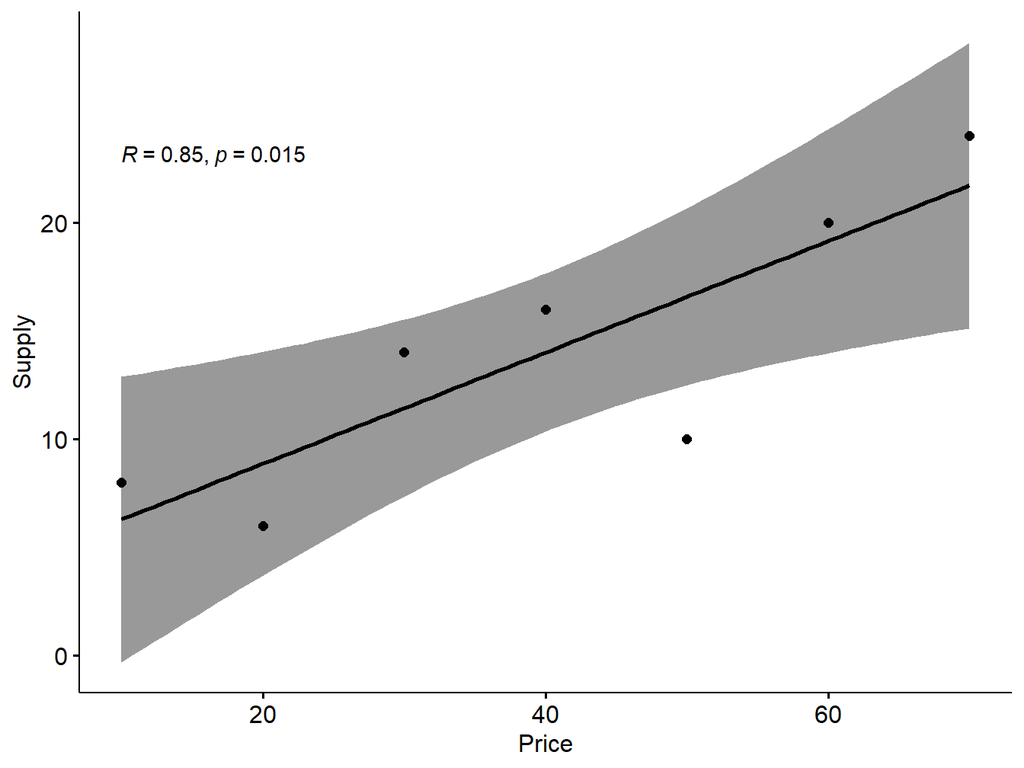

Scatter plot with smooth fit curve

```r
library(ggpubr)
ggscatter(my_data, x = "price", y = "supply",
          add = "reg.line", conf.int = TRUE,
          cor.coef = TRUE, cor.method = "pearson",
          xlab = "Price", ylab = "Supply")
```

## Results & discussions

Correlation coefficient of given bivariate data is calculated using built-in function in `stats` package. The result is verified using direct calculation.